# Lab 6: Linear Regression

Author

Yinjiao Zhong

Published

March 8, 2024

# 1 Exercise 1

```r
data("airquality")
head(airquality)
```

```
  Ozone Solar.R Wind Temp Month Day
1    41     190  7.4   67     5   1
2    36     118  8.0   72     5   2
3    12     149 12.6   74     5   3
4    18     313 11.5   62     5   4
5    NA      NA 14.3   56     5   5
6    28      NA 14.9   66     5   6
```

```r
?airquality
```

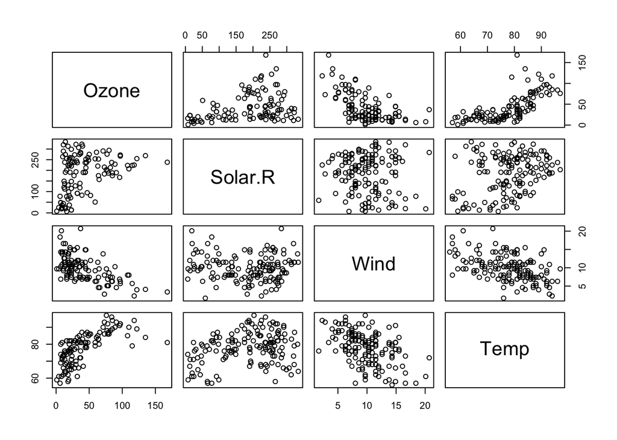

```r
# get airqulity of scatter plot
pairs(airquality[, c("Ozone", "Solar.R", "Wind", "Temp")])
```

```r
cor(airquality[, c("Ozone", "Solar.R", "Wind", "Temp")], use = "complete.obs")
```

```
             Ozone    Solar.R       Wind       Temp
Ozone    1.0000000  0.3483417 -0.6124966  0.6985414
Solar.R  0.3483417  1.0000000 -0.1271835  0.2940876
Wind    -0.6124966 -0.1271835  1.0000000 -0.4971897
Temp     0.6985414  0.2940876 -0.4971897  1.0000000
```

## 1.1 Question 1.1

**Answer**: The correlation between `Ozone` and `Wind` is -0.6124966. As the ozone level increases, the wind speed will decrease. In my opinion, this is a moderate to strong negative correlation.

## 1.2 Question 1.2

**Answer**:  
The correlation between `Ozone` and `Solar.R` is 0.3483417. As the ozone level increases, the Solar R will increase. In my opinion, this is a weak to moderate positive correlation.

# 2 Exercise 2

```r
set.seed(15165)

f <- function(x) {
 y <- -(x+3)^2 + runif(length(x), min = -2, max = 2)
}

f1 <- function(x) {
  y <- runif(length(x), min = min(x), max = max(x))
}

x <- seq(from = -6, to = 0, by = 0.005)
var1 <- f(x)
var2 <- f1(x)
var3 <- x
cor(var1, var2)
```

```
[1] -0.008598336
```

```r
cor(var1, var3)
```

```
[1] 2.843496e-05
```

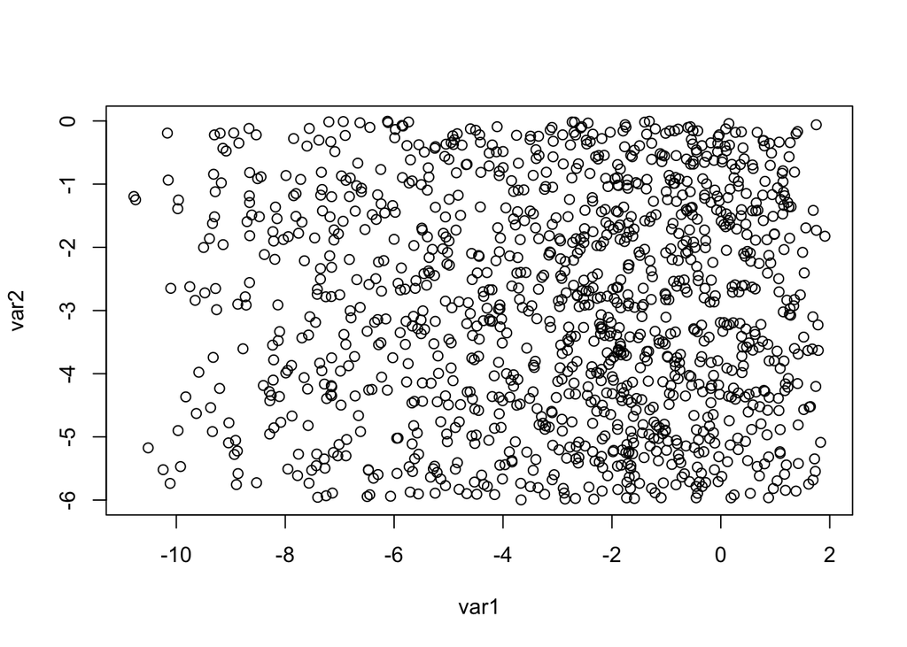

```r
plot(var2 ~ var1)
```

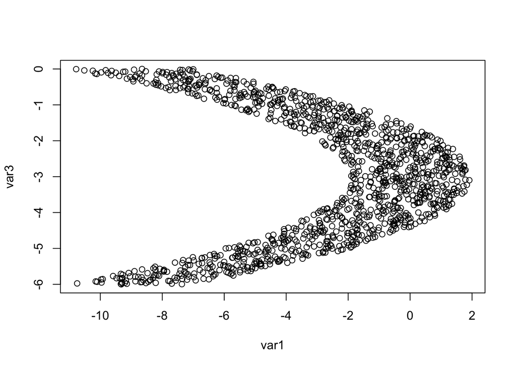

```r
plot(var3 ~ var1)
```

## 2.1 Question 2.1

```r
head(faithful)
```

```
  eruptions waiting
1     3.600      79
2     1.800      54
3     3.333      74
4     2.283      62
5     4.533      85
6     2.883      55
```

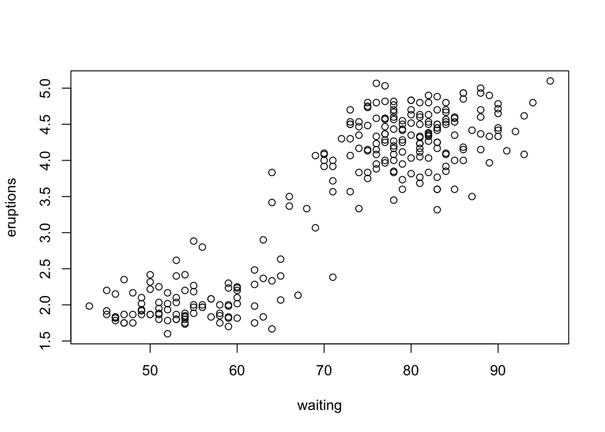

```r
# Plot waiting against eruptions
plot(eruptions~waiting, data=faithful)
```

## 2.2 Question 2.2

```r
# Calculate the correlation coefficient
cor(faithful$eruptions, faithful$waiting)
```

```
[1] 0.9008112
```

# 3 Exercise 3

```r
# Bulid linear model
mod <- lm(Temp ~ Wind, data = airquality)
summary(mod)
```

```
Call:
lm(formula = Temp ~ Wind, data = airquality)

Residuals:
    Min      1Q  Median      3Q     Max
-23.291  -5.723   1.709   6.016  19.199

Coefficients:
            Estimate Std. Error t value Pr(>|t|)
(Intercept)  90.1349     2.0522  43.921  < 2e-16 ***
Wind         -1.2305     0.1944  -6.331 2.64e-09 ***
---
Signif. codes:  0 '***' 0.001 '**' 0.01 '*' 0.05 '.' 0.1 ' ' 1

Residual standard error: 8.442 on 151 degrees of freedom
Multiple R-squared:  0.2098,    Adjusted R-squared:  0.2045
F-statistic: 40.08 on 1 and 151 DF,  p-value: 2.642e-09
```

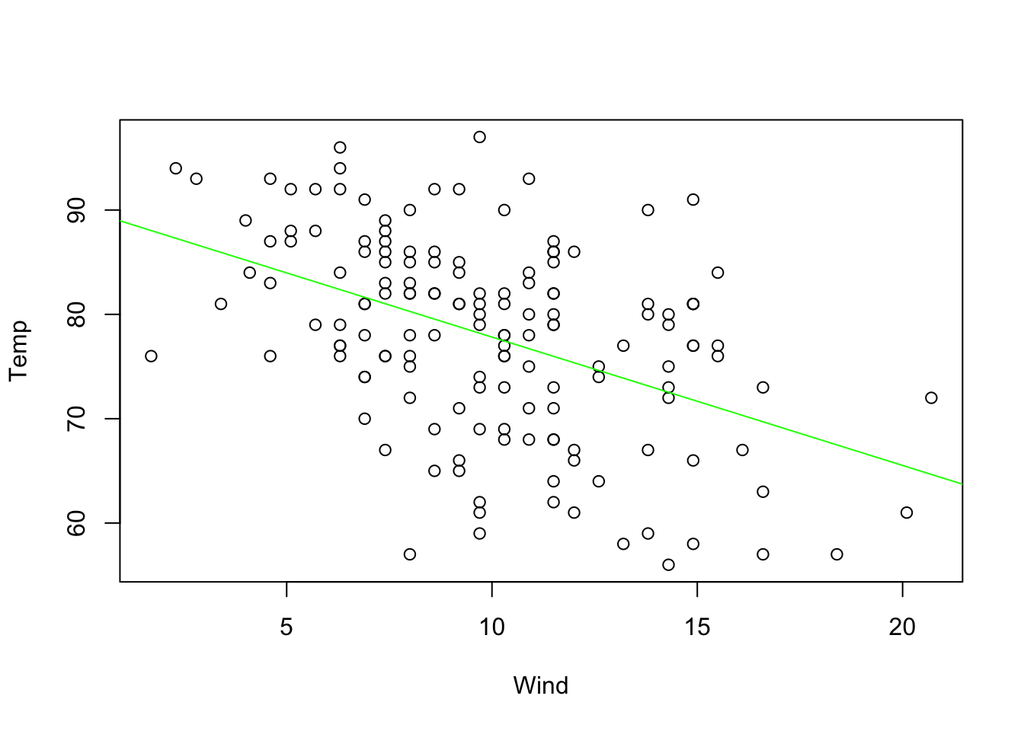

```r
plot(Temp ~ Wind, data = airquality)
abline(lm(Temp ~ Wind, data = airquality), col = "green")
```

## 3.1 Question 3.1

Notes: For full points, include model, interpretation and plot.

For a complete interpretation, include slope significance (alpha and p-value), slope and R2 interpretation, and intercept value with alpha and p-value.

```r
# Build linear model
mod <- lm(Temp ~ Ozone, data = airquality)
summary(mod)
```

```
Call:
lm(formula = Temp ~ Ozone, data = airquality)

Residuals:
    Min      1Q  Median      3Q     Max
-22.147  -4.858   1.828   4.342  12.328

Coefficients:
            Estimate Std. Error t value Pr(>|t|)
(Intercept) 69.41072    1.02971   67.41   <2e-16 ***
Ozone        0.20081    0.01928   10.42   <2e-16 ***
---
Signif. codes:  0 '***' 0.001 '**' 0.01 '*' 0.05 '.' 0.1 ' ' 1

Residual standard error: 6.819 on 114 degrees of freedom
  (37 observations deleted due to missingness)
Multiple R-squared:  0.4877,    Adjusted R-squared:  0.4832
F-statistic: 108.5 on 1 and 114 DF,  p-value: < 2.2e-16
```

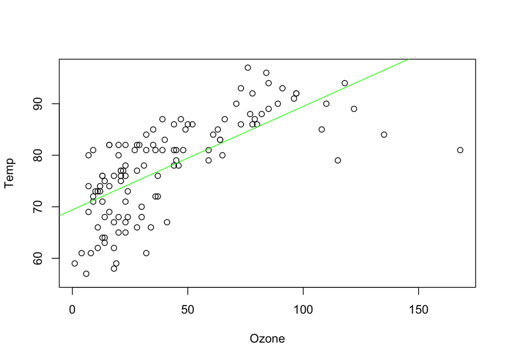

```r
# Plot scatterplot with estimated regression line
plot(Temp ~ Ozone, data = airquality)
abline(lm(Temp ~ Ozone, data = airquality), col="green")
```

**Answer:** The slope of this linear regression model is 0.20081. This means for every 1 unit increase in ozone, the temperature increases by 0.20081. The P value of the slope is 2×10⁻¹⁶<< alpha=0.05. So we can reject $H_0$:slope=0, there is a significant relationship between ozone and temperature.

R²=0.4877 of the variation in temperature is explained by ozone.

The intercept is 69.41072. This means when ozone is zero, temperature is predicted to be 69.41072. The intercept has a p value of 2×10⁻¹⁶<< alpha=0.05, meaning when ozone is zero, the temperature is significantly different from zero.

## 3.2 Question 3.2

Note: For full points, include model, interpretation and plot.

```r
# Build linear model
mod <- lm(eruptions~waiting, data=faithful)
summary(mod)
```

```
Call:
lm(formula = eruptions ~ waiting, data = faithful)

Residuals:
     Min       1Q   Median       3Q      Max
-1.29917 -0.37689  0.03508  0.34909  1.19329

Coefficients:
             Estimate Std. Error t value Pr(>|t|)
(Intercept) -1.874016   0.160143  -11.70   <2e-16 ***
waiting      0.075628   0.002219   34.09   <2e-16 ***
---
Signif. codes:  0 '***' 0.001 '**' 0.01 '*' 0.05 '.' 0.1 ' ' 1

Residual standard error: 0.4965 on 270 degrees of freedom
Multiple R-squared:  0.8115,    Adjusted R-squared:  0.8108
F-statistic:  1162 on 1 and 270 DF,  p-value: < 2.2e-16
```

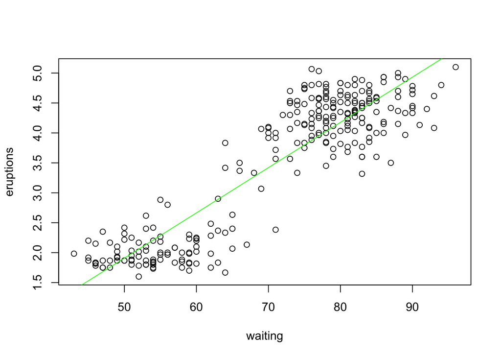

```r
#Plot scatterplot with estimated regression line
plot(eruptions~waiting, data=faithful)
abline(mod, col='green')
```

**Answer:** The slope is 0.075628. This means for every 1 unit increase in waiting time, the eruption time increases by 0.075628. The P value of the slope is 2×10⁻¹⁶<< alpha=0.05. So we can reject $H_0$:slope=0, there is a significant relationship between waiting and eruptions.

R²=0.8115 of the variation in eruptions is explained by waiting time.

The intercept is -1.874016. This means when waiting time is zero, eruption time is predicted to be -1.874016. The intercept has a p value of 2×10⁻¹⁶<< alpha=0.05, meaning when waiting time is zero the eruption time is significantly different from zero.

# 4 Exercise 4

## 4.1 Question 4.1

Note: To receive full credit, answer the three parts.

```r
mod <- lm(Temp~Wind, data=airquality)
r2 <- summary(mod)$r.squared
# Calculate SSY
y <- airquality$Temp
meany <- mean(y)
diff <- y-meany
SSY <- sum(diff^2)
# Calculate SSYp
x <- data.frame(Wind=airquality$Wind)
predy <- predict.lm(mod, x)
diff <- predy-meany
SSYp <- sum(diff^2)
# Calculate SSE
diff <- predy-y
SSE <- sum(diff^2)
SSE
```

```
[1] 10761.49
```

```r
# Verify SSY - SSYp = SSE
SSY-SSYp==SSE
```

```
[1] TRUE
```

## 4.2 Question 5.1

Note: Your final answer should include three parts: the model, tests for assumptions of homoscedasticity (perform all 3) and normality (perform both shapiro.test and qqPlot) and interpret of the results of homoscedasticity and normality tests.

```r
library(lmtest)
library(car)
library(dplyr)
# delete NAs
dat.airquality <- airquality %>%
  select(Temp, Ozone) %>%
  na.omit()
# Create linear model
mod <- lm(Temp~Ozone, data=dat.airquality)
summary(mod)
```

```
Call:
lm(formula = Temp ~ Ozone, data = dat.airquality)

Residuals:
    Min      1Q  Median      3Q     Max
-22.147  -4.858   1.828   4.342  12.328

Coefficients:
            Estimate Std. Error t value Pr(>|t|)
(Intercept) 69.41072    1.02971   67.41   <2e-16 ***
Ozone        0.20081    0.01928   10.42   <2e-16 ***
---
Signif. codes:  0 '***' 0.001 '**' 0.01 '*' 0.05 '.' 0.1 ' ' 1

Residual standard error: 6.819 on 114 degrees of freedom
Multiple R-squared:  0.4877,    Adjusted R-squared:  0.4832
F-statistic: 108.5 on 1 and 114 DF,  p-value: < 2.2e-16
```

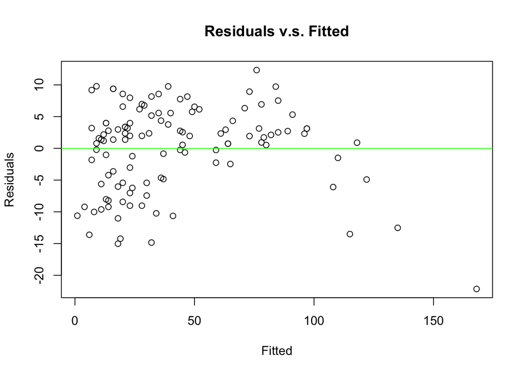

```r
# Check whether the model meets assumptions
plot(residuals(mod)~Ozone, data=dat.airquality,
     main='Residuals v.s. Fitted', xlab='Fitted', ylab='Residuals')
abline(h=0, col='green')
```

```r
# Statistical test
bptest(mod)
```

```
    studentized Breusch-Pagan test

data:  mod
BP = 3.2346, df = 1, p-value = 0.0721
```

**Result**: The p value of the Breush-Pegan test is 0.0721 > alpha = 0.05. So we fail to reject $H_0$: The variance is constant. Therefore, the requirement of homoscedasticity is met.

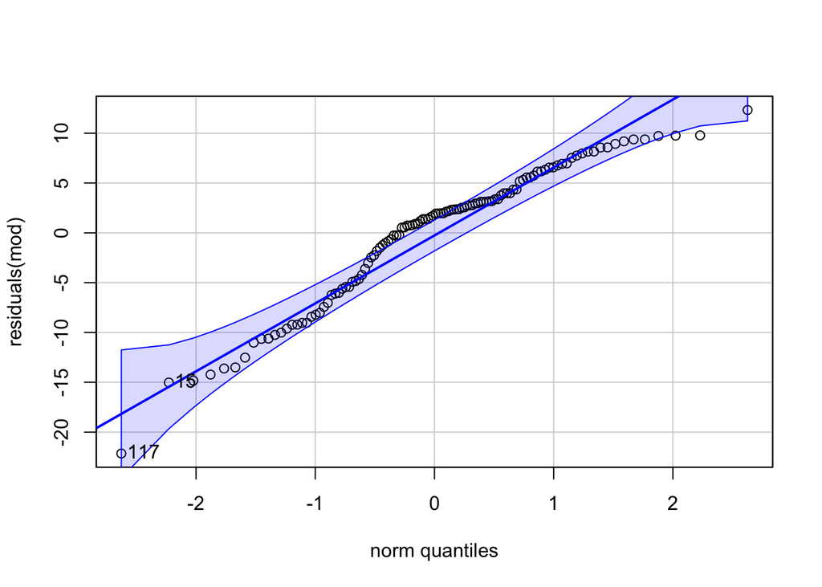

```
117  15
 82  13
```

```r
# get qqplot
qqPlot(residuals(mod))
```

```r
# Shapiro-Wilk test
shapiro.test(residuals(mod))
```

```
    Shapiro-Wilk normality test

data:  residuals(mod)
W = 0.94867, p-value = 0.000226
```

**Result**: We could know some laid out of the intervals from the Q-Q plot. From the Shapiro-Wilk test, the p value is 0.000226 < alpha = 0.05. So we can reject $H_0$: the data being tested are drawn from a normally distributed population. Therefore, the requirement of residual normality is NOT met.